# Effect of hatching condition on gene expression

J. Ignacio Lucas Lledó

# Model 1

Model 1 is expected to be the most sensitive to detect genes the expression of which is affected by enforcing diapause, after accounting for the variation among populations (which includes variation due to selective regime).

```r
qlf1 <- glmQLFTest(fit1)
topTags(qlf1)
```

```
## Coefficient:  diapausediapause
##                     logFC     logCPM        F       PValue       FDR
## TCONS_00075780 -3.1764026 -0.3164783 87.27115 7.244519e-06 0.2385258
## TCONS_00066966 -2.4700837 -0.3933047 56.25930 4.119853e-05 0.4729734
## TCONS_00065260 -2.0911696 -0.6323556 55.60755 4.309552e-05 0.4729734
## TCONS_00003139 -2.5576009  1.8623899 47.30525 7.993445e-05 0.6579605
## TCONS_00064093 -2.0791238  0.4548827 39.91429 1.506917e-04 0.7157760
## TCONS_00068658 -0.7212474  6.3625181 36.48838 2.092055e-04 0.7157760
## TCONS_00006143  1.6227212 -0.1176734 34.98506 2.435680e-04 0.7157760
## TCONS_00029970 -0.9225731  3.9659054 34.90854 2.454957e-04 0.7157760
## TCONS_00039858 -2.3088341 -1.2649910 34.26405 2.624986e-04 0.7157760
## TCONS_00011735 -1.0684960  3.4450536 34.25053 2.628707e-04 0.7157760
```

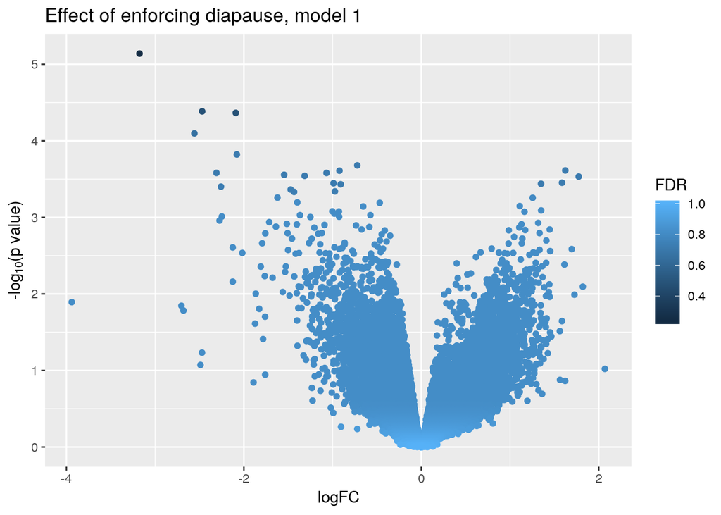

```r
z1 <- topTags(qlf1, n=NumOfTags)$table
z1$logPValue <- -log10(z1$PValue)
ggplot(data=z1, mapping=aes(x=logFC, y=logPValue, color=FDR)) +
   geom_point() + theme_grey() + ylab(expression(paste("-log"[10], plain("(p value)")))) +
   ggtitle('Effect of enforcing diapause, model 1')
```

```r
write.table(topTags(qlf1, n=NumOfTags), file=sprintf("%s/hatching.txt", args[2]), quote=FALSE)
```

# Model 2

Model 2 is very simple, and may include false positives, because it does not account for any interaction, nor for among-population variance.

```r
qlf2 <- glmQLFTest(fit2, coef=3)
topTags(qlf2)
```

```
## Coefficient:  diapausediapause
##                     logFC     logCPM        F       PValue       FDR
## TCONS_00075780 -3.1943494 -0.3213804 50.19249 8.523615e-06 0.1296082
## TCONS_00065260 -2.0927782 -0.6357618 49.30690 9.352737e-06 0.1296082
## TCONS_00003139 -2.5584129  1.8612144 47.13744 1.180941e-05 0.1296082
## TCONS_00066966 -2.5057699 -0.3955658 35.64548 4.789109e-05 0.3064585
## TCONS_00057853 -2.2440839  0.5642164 33.65855 6.313391e-05 0.3064585
## TCONS_00039858 -2.2497406 -1.2695655 32.63228 7.317018e-05 0.3064585
## TCONS_00045909 -1.3574387  3.4365378 32.58517 7.367345e-05 0.3064585
## TCONS_00068658 -0.7023335  6.3624992 30.71583 9.729233e-05 0.3064585
## TCONS_00066968 -2.2974892  1.6932906 30.57034 9.947215e-05 0.3064585
## TCONS_00016652 -0.9573694  2.8064409 30.40543 1.020115e-04 0.3064585
```

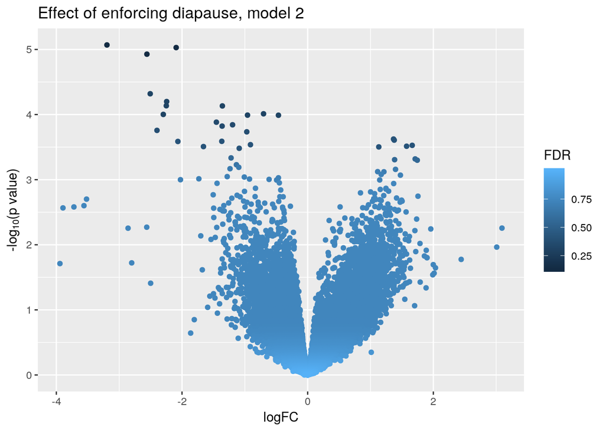

```r
z1 <- topTags(qlf2, n=NumOfTags)$table
z1$logPValue <- -log10(z1$PValue)
ggplot(data=z1, mapping=aes(x=logFC, y=logPValue, color=FDR)) +
   geom_point() + theme_grey() + ylab(expression(paste("-log"[10], plain("(p value)")))) +
   ggtitle('Effect of enforcing diapause, model 2')
```

According to model 2, there are 0 tags significantly up- or downregulated by hatching condition, at FDR=0.1.

# Model 3

In model 3, the effect of diapause may be understood in two different ways. First, we may want to know what genes have an average expression level different between hatching conditions. This is different from testing the effect of hatching condition twice: first among samples in a regular environment and then among those in the stochastic environment. Then, I could select the genes with the same significant tendency in both selective regimes. I will start this analysis to the first option, comparing only average gene expression level.

```r
qlf3 <- glmQLFTest(fit3, contrast=c(-0.5, 0.5, -0.5, 0.5))
topTags(qlf3)
```

```
## Coefficient:  -0.5*combinedRegulHatch 0.5*combinedRandDiap -0.5*combinedRandHatch 0.5*combinedRegulDiap
##                     logFC     logCPM        F       PValue       FDR
## TCONS_00003139 -2.5237449  1.8609252 58.51207 6.418491e-06 0.1993512
## TCONS_00065260 -2.1649049 -0.6366429 49.72429 1.431840e-05 0.1993512
## TCONS_00075780 -3.2955584 -0.3226349 46.47588 1.984792e-05 0.1993512
## TCONS_00057853 -2.4091110  0.5634941 44.58239 2.421883e-05 0.1993512
## TCONS_00034103 -1.3499676  4.0916701 40.97554 3.608610e-05 0.2376270
## TCONS_00058280  1.2247852  2.7844586 32.70892 1.011500e-04 0.4377930
## TCONS_00066966 -2.4874088 -0.3961485 32.04266 1.108414e-04 0.4377930
## TCONS_00030747 -1.3986822  0.8720172 31.42397 1.208265e-04 0.4377930
## TCONS_00045909 -1.3593991  3.4364473 30.28123 1.421778e-04 0.4377930
## TCONS_00033760 -0.4651111  5.5828895 28.53918 1.838560e-04 0.4377930
```

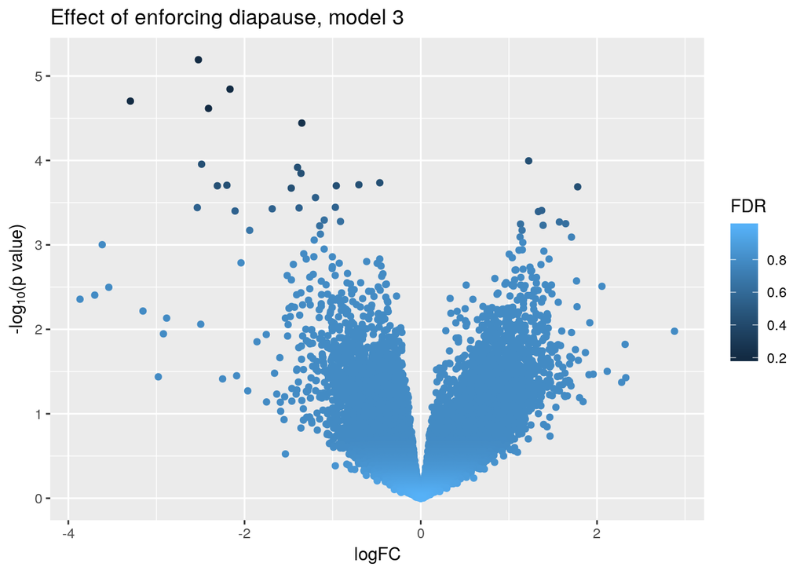

```r
z1 <- topTags(qlf3, n=NumOfTags)$table
z1$logPValue <- -log10(z1$PValue)
ggplot(data=z1, mapping=aes(x=logFC, y=logPValue, color=FDR)) +
   geom_point() + theme_grey() + ylab(expression(paste("-log"[10], plain("(p value)")))) +
   ggtitle('Effect of enforcing diapause, model 3')
```

According to model 3, there are 0 tags significantly up- or downregulated by hatching condition at FDR = 0.1.

For the sake of comparing model 3 to the results from Cuffdiff, I will make each one of the four possible comparisons, if analysing genes. The four coefficients of model correspond, in this order, to: regular regime and immediate hatching, random regime and diapause, random regime and hatching, and regular regime and diapause. In Eva’s terms, I believe they correspond to P1, I2, I1, and P2. However, Cuffdiff was not run on isoforms, but only genes.

```r
if (grepl('genes', input_file_name)) {
   #                                     P1 I2 I1 P2
   qlf3_1 <- glmQLFTest(fit3, contrast=c( 0,-1, 1, 0)) # I1vsI2
   qlf3_2 <- glmQLFTest(fit3, contrast=c( 1, 0, 0,-1)) # P1vsP2
   qlf3_3 <- glmQLFTest(fit3, contrast=c(-1, 0, 1, 0)) # I1vsP1
   qlf3_4 <- glmQLFTest(fit3, contrast=c( 0, 1, 0,-1)) # I2vsP2

   z1 <- topTags(qlf3_1, n=NumOfTags)$table
   z2 <- topTags(qlf3_2, n=NumOfTags)$table
   z3 <- topTags(qlf3_3, n=NumOfTags)$table
   z4 <- topTags(qlf3_4, n=NumOfTags)$table

   z1$inCuffdiff <- row.names(z1) %in% I1vsI2$geneid
   z2$inCuffdiff <- row.names(z2) %in% P1vsP2$geneid
   z3$inCuffdiff <- row.names(z3) %in% I1vsP1$geneid
   z4$inCuffdiff <- row.names(z4) %in% I2vsP2$geneid

   layout(mat=matrix(c(1,2,3,4), ncol=2, nrow=2, byrow=TRUE))
   qqplot(z1$PValue[z1$inCuffdiff], z1$PValue[!z1$inCuffdiff], xlab='Cuffdiff genes p-values', ylab='Other genes p-values', main='Hatching vs Diapause, when Random')
   qqplot(z2$PValue[z2$inCuffdiff], z2$PValue[!z2$inCuffdiff], xlab='Cuffdiff genes p-values', ylab='Other genes p-values', main='Hatching vs Diapause, when Regular')
   qqplot(z3$PValue[z3$inCuffdiff], z3$PValue[!z3$inCuffdiff], xlab='Cuffdiff genes p-values', ylab='Other genes p-values', main='Random vs Regular, when hatching')
   qqplot(z4$PValue[z4$inCuffdiff], z4$PValue[!z4$inCuffdiff], xlab='Cuffdiff genes p-values', ylab='Other genes p-values', main='Random vs Regular, when diapausing')
}
```

# Model 4

```r
qlf4 <- glmQLFTest(fit4, coef=3)
topTags(qlf4)
```

```
## Coefficient:  diapausediapause
##                     logFC     logCPM        F       PValue       FDR
## TCONS_00075780 -3.1764026 -0.3164783 87.27115 7.244519e-06 0.2385258
## TCONS_00066966 -2.4700837 -0.3933047 56.25930 4.119853e-05 0.4729734
## TCONS_00065260 -2.0911696 -0.6323556 55.60755 4.309552e-05 0.4729734
## TCONS_00003139 -2.5576009  1.8623899 47.30525 7.993445e-05 0.6579605
## TCONS_00064093 -2.0791238  0.4548827 39.91429 1.506917e-04 0.7157760
## TCONS_00068658 -0.7212474  6.3625181 36.48838 2.092055e-04 0.7157760
## TCONS_00006143  1.6227212 -0.1176734 34.98506 2.435680e-04 0.7157760
## TCONS_00029970 -0.9225731  3.9659054 34.90854 2.454957e-04 0.7157760
## TCONS_00039858 -2.3088341 -1.2649910 34.26405 2.624986e-04 0.7157760
## TCONS_00011735 -1.0684960  3.4450536 34.25053 2.628707e-04 0.7157760
```

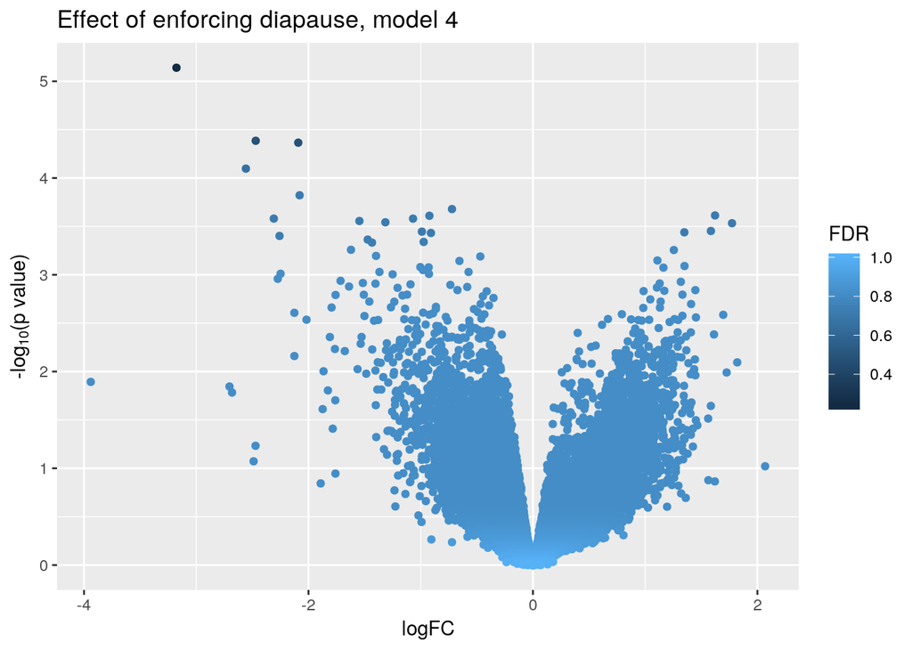

```r
z1 <- topTags(qlf4, n=NumOfTags)$table
z1$logPValue <- -log10(z1$PValue)
ggplot(data=z1, mapping=aes(x=logFC, y=logPValue, color=FDR)) +
   geom_point() + theme_grey() + ylab(expression(paste("-log"[10], plain("(p value)")))) +
   ggtitle('Effect of enforcing diapause, model 4')
```

According to model 4, there are 0 tags significantly up- or downregulated by hatching condition at FDR = 0.1.

# Model 5

```r
qlf5 <- glmQLFTest(fit5, coef=3)
topTags(qlf5)
```

```
## Coefficient:  diapausediapause
##                     logFC     logCPM        F       PValue       FDR
## TCONS_00003139 -3.1667715  1.8609252 45.62175 2.169430e-05 0.5594549
## TCONS_00073422 -2.3699781  0.3573781 41.50302 3.398359e-05 0.5594549
## TCONS_00061427  2.7235326 -1.1544340 34.65022 7.808930e-05 0.8570301
## TCONS_00012716  1.8955543  0.4594967 26.79424 2.406782e-04 0.9035254
## TCONS_00075780 -3.0370409 -0.3226349 26.60638 2.479447e-04 0.9035254
## TCONS_00065474  1.6624489 -0.8320652 24.61866 3.429358e-04 0.9035254
## TCONS_00046899 -0.9014119  4.7544705 23.40107 4.221982e-04 0.9035254
## TCONS_00065260 -1.8688083 -0.6366429 23.01763 4.514729e-04 0.9035254
## TCONS_00031359  1.8597135  0.8252685 22.20952 5.213270e-04 0.9035254
## TCONS_00012517 -1.6034290 -1.0525963 21.23805 6.227523e-04 0.9035254
```

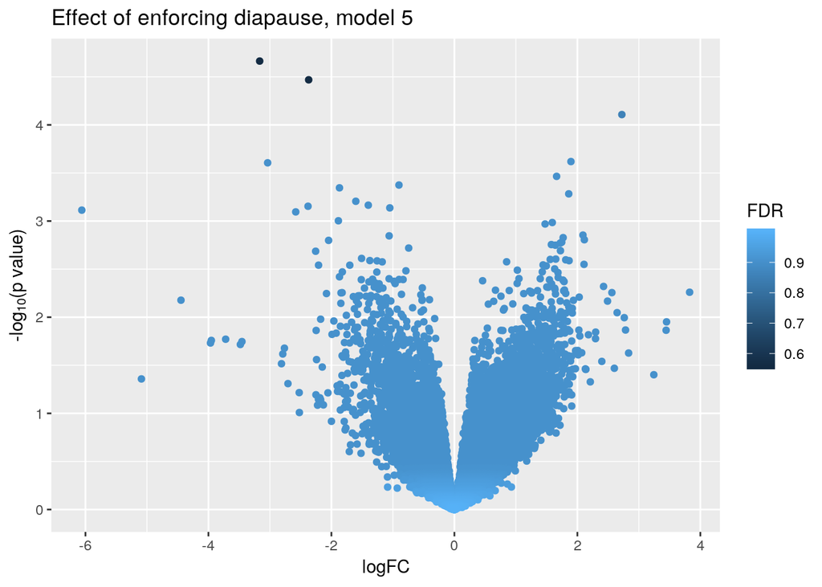

```r
z1 <- topTags(qlf5, n=NumOfTags)$table
z1$logPValue <- -log10(z1$PValue)
ggplot(data=z1, mapping=aes(x=logFC, y=logPValue, color=FDR)) +
   geom_point() + theme_grey() + ylab(expression(paste("-log"[10], plain("(p value)")))) +
   ggtitle('Effect of enforcing diapause, model 5')
```

According to model 5, there are 0 tags significantly up- or downregulated by hatching condition at FDR = 0.1.

# Model 6

```r
qlf6 <- glmQLFTest(fit6, coef=3)
topTags(qlf6)
```

```
## Coefficient:  diapausediapause
##                    logFC     logCPM        F       PValue       FDR
## TCONS_00003139 -3.183579  1.8617487 57.11781 8.549787e-05 0.9482227
## TCONS_00061427  2.664631 -1.1550477 55.46156 9.448442e-05 0.9482227
## TCONS_00075780 -3.040333 -0.3191142 48.27772 1.506918e-04 0.9482227
## TCONS_00073422 -2.327502  0.3569712 41.37848 2.508920e-04 0.9482227
## TCONS_00066966 -2.586594 -0.3945174 31.76613 5.860462e-04 0.9482227
## TCONS_00043129  1.827538 -0.9309368 30.44470 6.694247e-04 0.9482227
## TCONS_00011325  2.325938 -1.7953157 30.14818 6.901582e-04 0.9482227
## TCONS_00070211  1.195713  2.9754349 28.76705 7.981708e-04 0.9482227
## TCONS_00002778 -2.097683  1.3614324 27.60294 9.063003e-04 0.9482227
## TCONS_00065260 -1.865695 -0.6341799 27.17919 9.502242e-04 0.9482227
```

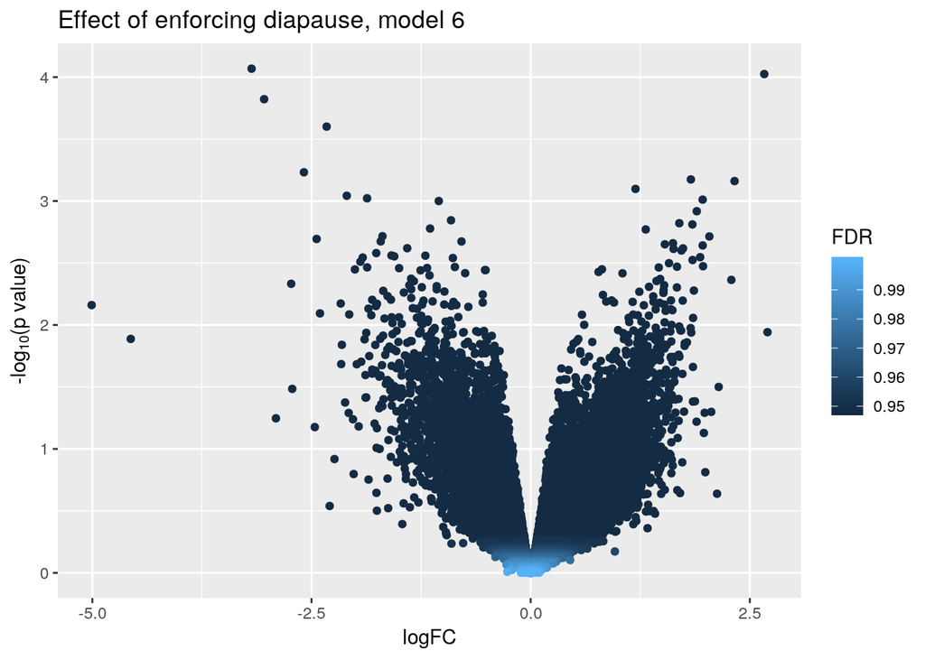

```r
z1 <- topTags(qlf6, n=NumOfTags)$table
z1$logPValue <- -log10(z1$PValue)
ggplot(data=z1, mapping=aes(x=logFC, y=logPValue, color=FDR)) +
   geom_point() + theme_grey() + ylab(expression(paste("-log"[10], plain("(p value)")))) +
   ggtitle('Effect of enforcing diapause, model 6')
```

According to model 6, there are 0 tags significantly up- or downregulated by hatching condition at FDR = 0.10. And this is how the results from models 1, 2, 3 and 4 match:

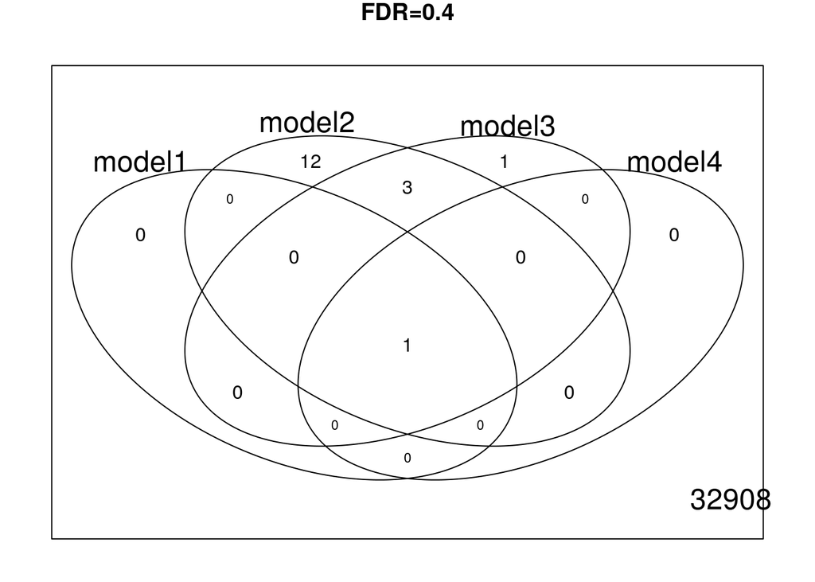

```r
significant <- cbind(model1 = topTags(qlf1, n=NumOfTags, sort.by='none')$table$FDR <= 0.4,
                     model2 = topTags(qlf2, n=NumOfTags, sort.by='none')$table$FDR <= 0.4,
                     model3 = topTags(qlf3, n=NumOfTags, sort.by='none')$table$FDR <= 0.4,
                     model4 = topTags(qlf4, n=NumOfTags, sort.by='none')$table$FDR <= 0.4)
vennDiagram(vennCounts(significant), main='FDR=0.4')
```